# Boletin EMMET

Subdirección

2023-03-09

#Encuesta Mensual Manufacturera con Enfoque Territorial – EMMET Noviembre 2022

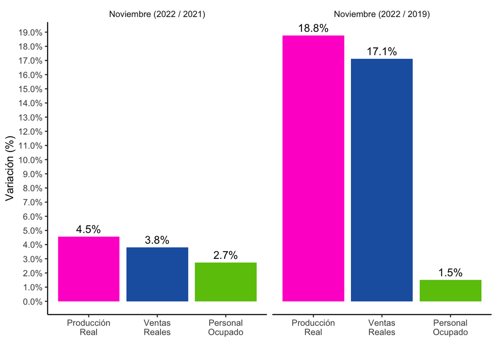

## Introducción

La Encuesta Mensual Manufacturera con Enfoque Territorial (EMMET), es una investigación de carácter estadístico por medio de la cual el Departamento Administrativo Nacional de Estadística (DANE) obtiene la información de evolución de las principales variables económicas del sector fabril colombiano en el corto plazo.

La EMMET mide la evolución mensual del sector manufactrero del país, a través de las variables de producción, ventas, empleo, sueldos y horas trabajadas; con ellas el DANE genera índice, variaciones y contribuciones; es también una herramienta importante para la elaboración de las estimaciones del Producto Interno Bruto (PIB) del sector industrial que realiza la Dirección Técnica de Síntesis y Cuentas Nacionales.

Tomando como marco la Encuesta Anual Manufacturera de 2017, se realizó el último rediseño de la operación estadística. Sobre este año base, se obtuvo una encuesta por muestreo no probabilístico de 3.100 establecimientos; con ellos se presentan los resultados a nivel total nacional y su desagregación para 12 departamentos, Bogotá y otros departamentos, 3 áreas metropolitanas y 8 ciudades del país, para los diferentes usuarios públicos y privado. En el contexto nacional, se mantienen 39 dominios industriales manufactureros de publicación establecidos con base en la Clasificación Industrial Internacional Uniforme (CIIU) de toas las actividades económicas Rev. 4 adaptada para Colombia.De esta forma es posible obtener la información necesaria para construir indicadores confiables de la industria manufacturera, los cuales son herramientas importantes para la toma de decisioneseconómicas en el país.

## Evolución general de las principales variables total nacional Noviembre 2022

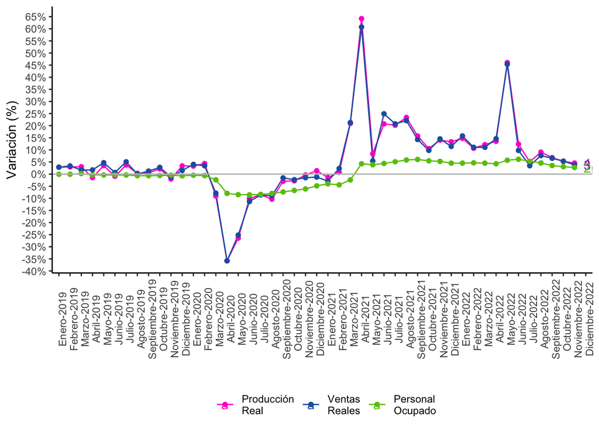

### 1.1 Variación anual (%) y contribución, del valor de la producción, ventas y empleo total, segpun clase industrial

[output not shown]